# Computer Science 1

**Computer lab 08**

**Course Number:** BTPS1210BA-E  
**Contact Information:** Please contact me through email anytime: abari.kalman@arts.unideb.hu

Author

Kálmán Abari

Published

August 31, 2024

Learning outcomes

Students will learn how to run descriptive analysis in *jamovi*.

# Jamovi - Descriptive statistics I.

## Problem 1

> In this section, you will learn how to explor nominal data.

The `comics.csv` dataset has information on all comic characters that have been introduced by DC and Marvel. The variables:

- `name` - Name of the character - **ID**
- `id` - Personal identity of comic book characters - **Nominal** - Levels: “No Dual”, “Public”, “Secret”, “Unknown”
- `align` - Alignment of comic book characters - **Nominal** - Levels: “Bad”, “Good”, “Neutral”, “Reformed Criminals”
- `eye` - Eye colour - **Nominal** - Levels: “Amber Eyes”, …
- `hair` - Hair colour - **Nominal** - Levels: “Auburn Hair”, …
- `gender` - Gender - **Nominal** - Levels: “Female”, “Male”, “Other”
- `gsm` - Gender and sexuality minorities - **Nominal** - Levels: “Bisexual Characters”, …
- `alive` - Is the character alive or dead? - **Nominal** - Levels: “Deceased Characters”, “Living Characters”
- `appearances` - All appearances of the character - **Continuous**
- `first_appear` - Firs appear of the character - **Nominal** - Levels: “Aug-62”, …
- `publisher` - Publisher Company - **Nominal** - Levels: “dc”, “marvel”
1. Download `comics.csv` from [here](https://github.com/abarik/computer_science_1_2023_24_1/blob/0bc509cf034f1ff162759dec817ef3d87c09152f/files/comics.csv). Open `comics.csv` dataset in *jamovi*.
2. Check the measurement type of the variables and provide a description for each variable.

[figure not shown]

Review variables

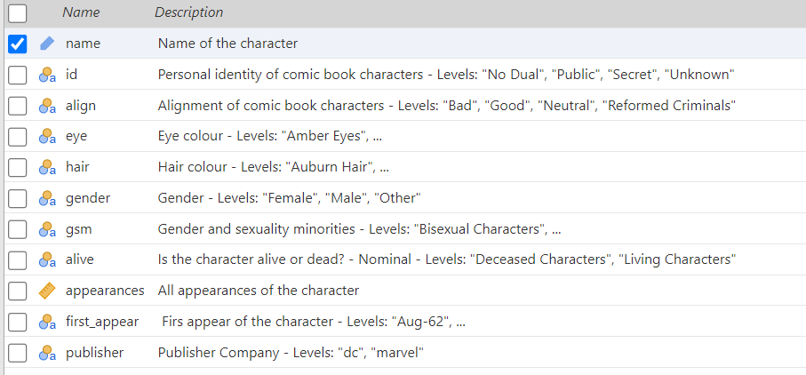

Review variables in details

3. Determine the number of rows and columns. Determine the number of observations and variables.

[figure not shown]

Number of rows (number of observations)

[figure not shown]

Number of columns (number of variables)

We have 23272 observations, or cases, or rows and 11 variables, or columns.

4. Two publishers, Marvel and DC, have created a host of superheroes that have made their way into popular culture. You’re probably familiar with Batman and Spiderman, but what about *Mor the Mighty* or *Samuel Guthrie*? Learn more about these two characters from the database.

[figure not shown]

Two characters

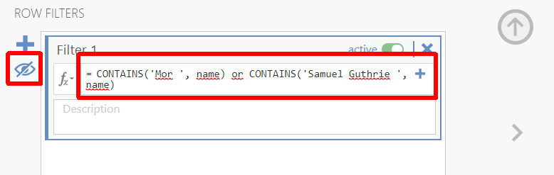

Filter with `or` and Hide filter columns

During filtering, use the filter condition above and select the `Hide filter columns` option, which also hides the filter columns and unnecessary rows. As we can see, both characters are from the Marvel universe and both are male.

After the examination, do not forget to deactivate the filter.

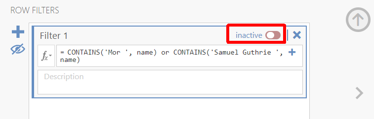

Deactivate filter

5. Check the number of valid and missing values for variable `align`, `gender` and `id`.

   Select `Analyses / Exploration / Descriptives` menu. Move the 3 variables into the ‘Variables’ box.

[figure not shown]

Valid and Missing values

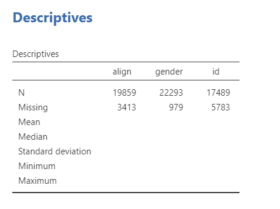

Valid and Missing values

The first output of descriptive statistical analyzes is the “missing data report”. Jamovi automatically recognises blank fields as missing values - no further action is needed unless you have other values that should be considered missing. The output above shows that the number of missing values is high. The number of valid data (non-missing values) in the `align` variable is 19859, while the number of missing values is 3413.

**Missing values**

Often, participants don’t answer every question on a questionnaire, observers miss a particular behavior, recording devices fail, there was a glitch in a program, or a participant’s results are lost. These kinds of situations create missing values. (When entering your data, it is usually best to leave the place blank where a missing value would go. If instead you put in some number like 999 or –1, it could end up being included in the figuring later!)

6. It’s clear that the alignment variable (`align`) can be “good” or “neutral”, but what other values are possible?

   The following labels (levels) are expected to appear in the descriptive statistics analysis:

[figure not shown]

Levels of a factor

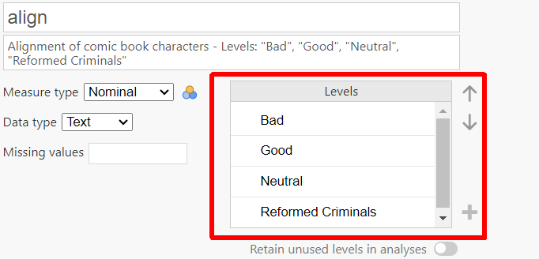

Levels of a factor

If we run `Setup` variable, we learn that there are in fact four possible alignments, including `Reformed Criminals`.

**Factor levels**

Factor is another way of referring to a categorical variable. (As you know, there are two kinds of categorical data: Nominal Data, Ordinal Data.) Factor levels are all of the values that the factor can take (recall that a categorical variable has a set number of groups).

7. How many times each value occurs in the `align` variable?

The usual way to determine the occurrence of each level is to display a frequency table. Select `Analyses / Exploration / Descriptives` menu. Move the `align` variable into the ‘Variables’ box, then switch on the `Frequency tables` check box.

[figure not shown]

Frequency table of a nominal valriable

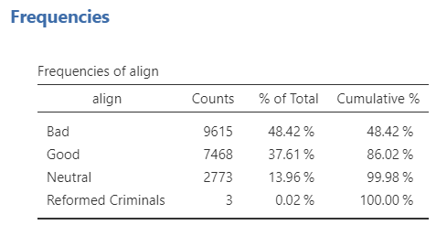

Frequency table of a nominal valriable

The frequency table indicates that `Bad` and `Good` characters are the most popular type of pet among alignments. `Neutral`s are rare characters in this factor. Three individuals are `Reformed Criminals`. Frequency tables can also give you information about modes for nominal and ordinal variables, proportions, and cumulative percentages that can be used to extract information about percentiles and percentile ranks. For example, 37.6% of the sample is a good character. For nominal variables, there is no natural order of levels, so we do not interpret the cumulative frequency.

**Frequency Table**

A frequency table lists a set of values and how often each one appears. Frequency is the number of times a specific data value occurs in a variable. These tables help you understand which data values are common and which are rare. These tables organize your data and are an effective way to present the results to others. Frequency tables are also known as frequency distributions because they allow you to understand the distribution of values in a variable.

Frequency distribution tables are a great way to find the mode for a variable.

8. Do the same (5-7. points) for identity (`id` variable), after selecteing `Analyses / Exploration / Descriptives` menu.

[figure not shown]

Levels of id variable

[figure not shown]

Frequency table

We learn that there are four possible identities.

9. Save and send the file `comics.omv` to the `abari.kurzus@gmail.com`. The subject of this email is `Lab08 - Problem 1`.

## Problem 2

> In this section, you will learn how to explor ordinal data.

The **Student Survey Data** looks at variables from a survey of over 200 students at the University of Adelaide. It can be downloaded from this [link](https://vincentarelbundock.github.io/Rdatasets/csv/MASS/survey.csv). You can find the codebook [here](https://vincentarelbundock.github.io/Rdatasets/doc/MASS/survey.html).

1. Open `survey.csv` dataset in *jamovi*.
2. Check the measurement type of the variables and provide a description for each variable.

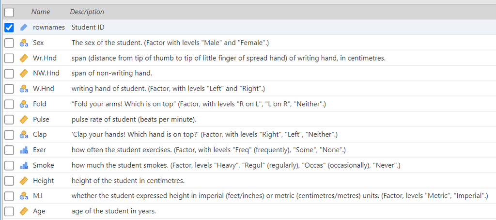

Review variables

3. Determine the number of rows and columns. Determine the number of observations and variables.

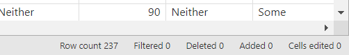

Number of rows (number of observations)

We have 237 observations, or cases, or rows and 13 variables, or columns.

4. Check again that the levels of the ordinal variables (`Exer`, `Smoke`) follow each other in increasing order of magnitude.

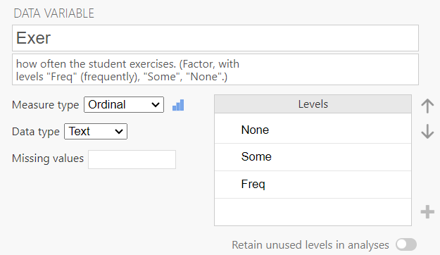

Order of levels in `Exer` factor

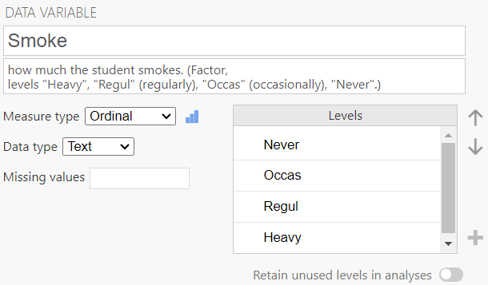

Order of levels in `Smoke` factor

5. Check the number of valid and missing values for ordinal variable `Exer` and `Smoke`.

   Select `Analyses / Exploration / Descriptives` menu. Move the 2 variables into the ‘Variables’ box.

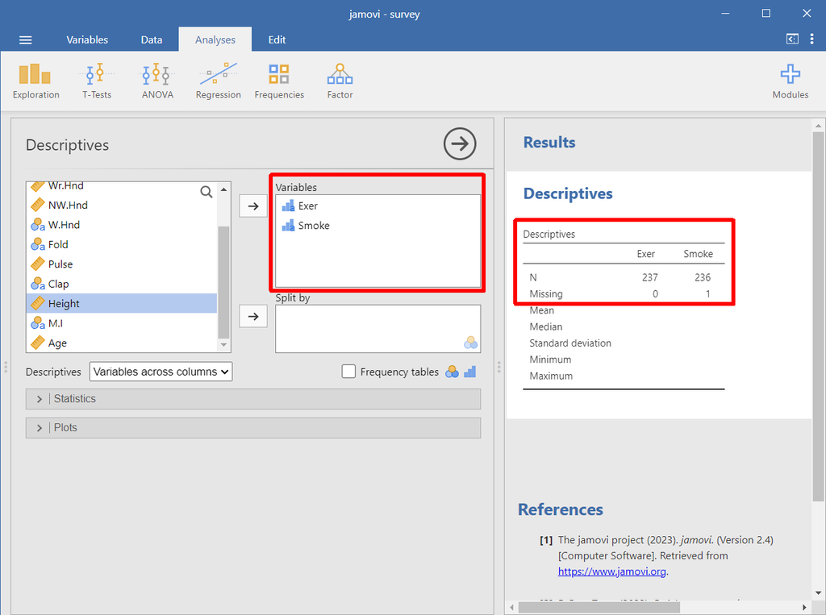

Valid and Missing values

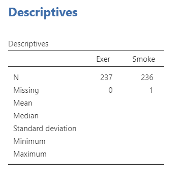

Valid and Missing values

There is no missing value in the variable `Exer`, we know how much exercise everyone does. The variable `Smoke` contains one missing value, i.e. the number of valid data is one less (236) than the number of sample elements.

6. Give a frequency table for the two ordinal variables and interpret them. Note that in the case of ordinal variables, the cumulative frequency can also be interpreted.

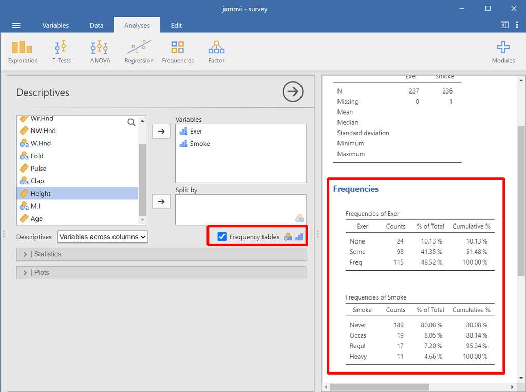

Frequency tables

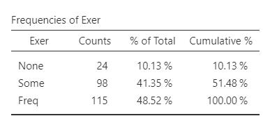

Frequency table for `Exer` variable

Regarding the variable `Exer`, the highest number of students who exercise frequently is 48.52% of the total sample, i.e. 115 students. Fewer are those who do some physical activity (98 students, 41.35% of the sample) and the fewest are those who do no physical activity at all. The latter group includes 24 students, representing 10.13% of the sample. Looking at the cumulative frequencies, for example, 51.48% of the sample does at most some physical activity.

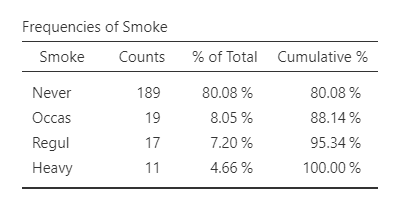

Frequency table for `Smoke` variable

After reviewing the frequency table of the variable `Smoke`, we can say that heavy smokers are the smallest, accounting for 4.66% of the sample (only 11), the percentage of regular smokers is 7.2% (17), the percentage of occasional smokers is 8.05% (19), and the largest number (189 students, 80.08% of the sample) is composed of non-smokers. The cumulative frequencies indicate that 88.14% of the sample are at most occasional smokers.

**Cumulative frequency**

Cumulative frequency means the sum of frequencies of the levels and all the levels below it. It is calculated by adding the frequency of each level lower than the corresponding level category.

9. Save and send the file `survey.omv` to the `abari.kurzus@gmail.com`. The subject of this email is `Lab08 - Problem 2`.

## Problem 3

> In this section, you will learn how to explor numerical data.

We will use data from **gapminder**, which tracks demographic data in countries of the world over time. It can be downloaded from this [link](https://vincentarelbundock.github.io/Rdatasets/csv/gapminder/gapminder.csv). You can find the codebook [here](https://vincentarelbundock.github.io/Rdatasets/doc/gapminder/gapminder.html).

For this problem, focus on how the life expectancy differs from continent to continent.

1. Open `gapminder.csv` dataset in *jamovi*. Delete the variable `rownames`.
2. Check the measurement type of the variables and provide a description for each variable.

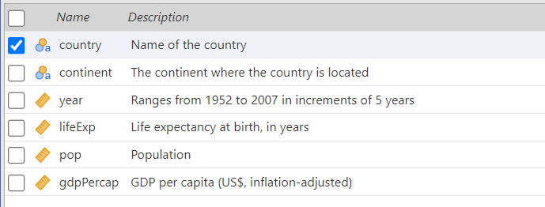

Review variables

3. Determine the number of rows and columns. Determine the number of observations and variables.

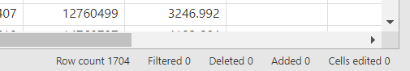

Number of rows (number of observations)

We have 1704 observations, or cases, or rows and 6 variables, or columns.

4. Learn more about all continuous variables. Determine the number of valid and missing values for these variables.

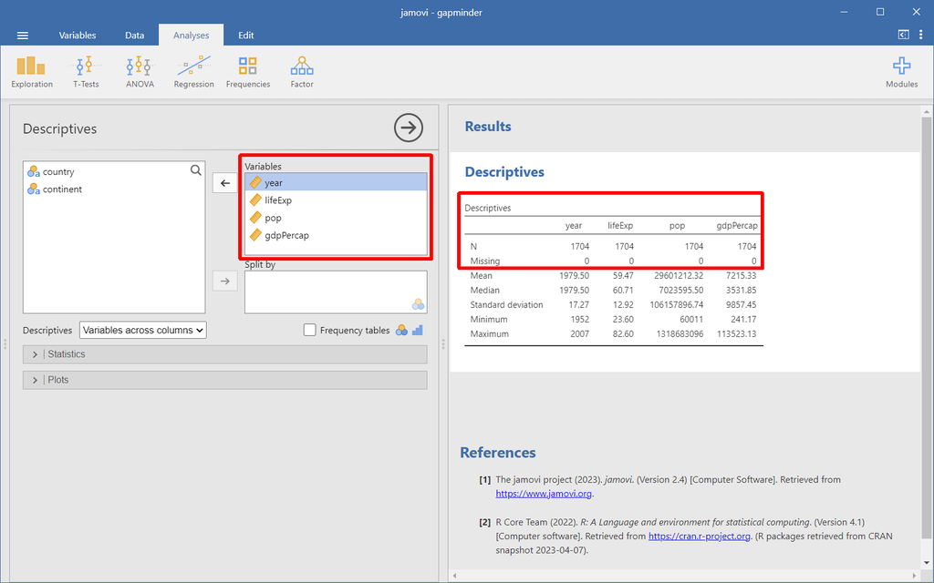

Valid and missing values

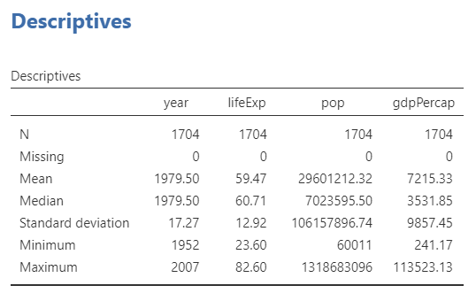

Figure 1: Valid and missing values

We can see that there are no missing values in the continuous variables.

   We can see that the data recorded in the database comes from the period 1952-2007 (based on minimum and maximum of variable `year`).

   What is the typical life expectancy? The most common answer is the mean (59.47), which is the sum of all of the observations divided by the number of observations. Another measure of “typical” or “center” is the median. The median is the middle value in the sorted dataset. So if we sort `lifeExp`, the middle value is 60.71.
6. A third measure of center is the mode. The mode is simply the most common observation in the set. Turn on and interpret additional metrics.

[figure not shown]

Metrics on the `Statistics` tab.

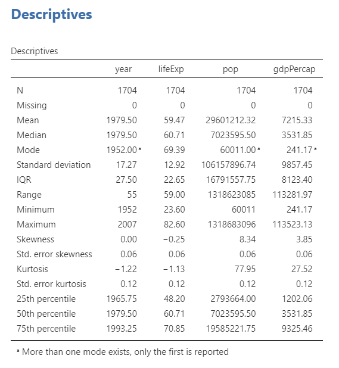

Figure 2: Descriptiv statistics

More metrics can be switched on in the `Statistics` tab:

- `Mode` - The mode is simply the most common observation in the set.
- `IQR` - The interquartile range (IQR) is a measure of statistical dispersion, which is the spread of the data. The IQR contains the middle 50% of sample. It is defined as the difference between the 75th and 25th percentiles of the data.
- `Range` - The Range is the difference between the lowest and highest values
- `Skewness` - Skewness is a measure of symmetry, or more precisely, the lack of symmetry. A distribution, or data set, is symmetric if it looks the same to the left and right of the center point.
- `Kurtosis` - Kurtosis is a measure of whether the data are heavy-tailed or light-tailed relative to a normal distribution. That is, data sets with high kurtosis tend to have heavy tails, or outliers. Data sets with low kurtosis tend to have light tails, or lack of outliers.
- `25th percentile` - Also known as the first, or lower, quartile. The 25th percentile is the value at which 25% of the answers lie below that value, and 75% of the answers lie above that value.
- `50th percentile` - The 50th percentile or median is the value in the very middle of a set of measurements. In other words, 50% of measurements are under the median and 50% are over the median.
- `75th percentile` - Also known as the third, or upper, quartile. The 75th percentile is the value at which 25% of the answers lie above that value and 75% of the answers lie below that value.

A third typical measure of variable `lifeExp` is 69.39 (based on mode of `lifeExp`).

9. Save and send the file `gapminder.omv` to the `abari.kurzus@gmail.com`. The subject of this email is `Lab08 - Problem 3`.

**Measures of center: mean, median, and mode**

It is not easy to answer the question of what a typical value is in a variable. The **mean** can be thought of as the balance point of the data and it tends to be drawn towards the longer tail of a distribution. This highlights an important feature of the mean: its sensitivity to extreme values. For this reason, when working with skewed distributions, the **median** is often a more appropriate measure of center.

Central tendency measures are statistical methods used to describe the center or typical value in a set of data. There are three primary measures of central tendency: the mean, the median, and the mode. Each of these measures provides a different way of summarizing the center of a dataset. Here’s a characterization of each:

- **Mean**
  - The mean, often referred to as the average, is calculated by summing up all the values in a dataset and dividing by the number of data points.
  - Formula: Mean = (Sum of all data points) / (Number of data points).
  - The mean is sensitive to extreme values or outliers in the dataset. It can be heavily influenced by large or small values, which may not represent the “typical” value when outliers are present.
- **Median**
  - The median is the middle value in a dataset when the values are arranged in ascending or descending order. If there is an even number of data points, the median is the average of the two middle values.
  - The median is not influenced by extreme values, making it a robust measure of central tendency. It represents the middle value, which is often a better choice when outliers are present.
- **Mode**
  - The mode is the most frequently occurring value in a dataset. A dataset may have no mode (if all values occur equally), one mode (if one value occurs most frequently), or multiple modes (if more than one value occurs with the same highest frequency).
  - The mode is particularly useful for categorical or nominal data, where values represent categories rather than numerical quantities. In such cases, the mode describes the most common category.

These three measures are complementary and can provide different insights into a dataset. The choice of which measure to use depends on the nature of the data and the specific research or analytical goals. It’s common to use all three measures in conjunction to gain a more complete understanding of the central tendency in a dataset.